# Анализ рынка недвижимости Санкт-Петербурга

### Исследование факторов, влияющих на стоимость квартиры

#### Зависимость стоимости квартиры от общей площади, количества комнат, удалённости от центра

Рассмотрим зависимость стоимости квартиры `'last_price'` от общей площади `'total_area'`, количества комнат `'rooms'`, удалённости от центра `'city_centers_nearest'`.

Построим матрицу попарной корреляции Пирсона для этих параметров:

```python
columns = ['last_price', 'total_area', 'rooms', 'city_centers_nearest']
good_realty[columns].corr().style.background_gradient('coolwarm')
```

|  | last_price | total_area | rooms | city_centers_nearest |
| --- | --- | --- | --- | --- |
| last_price | 1.000000 | 0.663150 | 0.415794 | -0.310143 |
| total_area | 0.663150 | 1.000000 | 0.806067 | -0.067345 |
| rooms | 0.415794 | 0.806067 | 1.000000 | -0.037550 |
| city_centers_nearest | -0.310143 | -0.067345 | -0.037550 | 1.000000 |

Заметно, что цена больше всего связана с общей площадью квартиры. В меньшей степени она зависит от количества комнат (возможно из-за того, что мы оставили в данных 0-комнатные квартиры).

Слабее всего цена зависит от расстояния до центра. При этом логично наблюдается обратная зависимость: чем меньше расстояние до центра, тем выше цена.

Количество комнат совершенно справедливо существенно зависит от площади.

А вот от расстояния до центра ни количество комнат, ни площадь квартир существенно не зависят. При этом коэффициенты корреляции намекают, что с увеличением расстояния до центра площадь и количество комнат слегка снижаются.

Построим попарные диаграммы рассеивания для данных столбцов для иллюстрации указанных закономерностей:

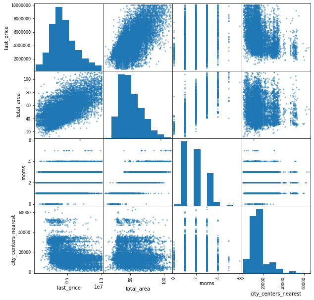

```python
pd.plotting.scatter_matrix(good_realty[columns],
                          grid=True, figsize=(10, 10))
plt.show()
```

Зависимость цены от площади прослеживается чётко. Также заметно, что с увеличением количества комнат (не рассматривая 0) растёт и цена. Зависимость цены от удалённости (правый верхний угол) - слабая и обратная.

Построим графики зависимости цены от указанных параметров:

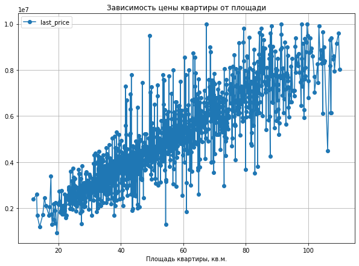

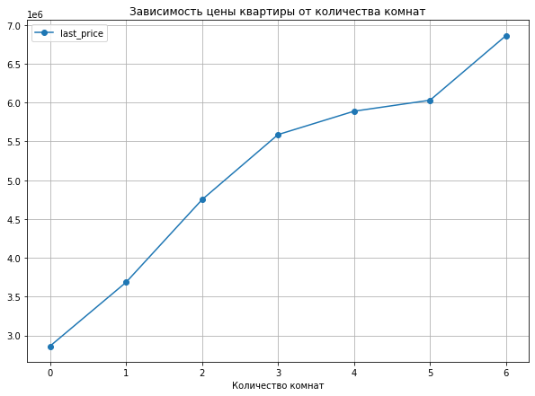

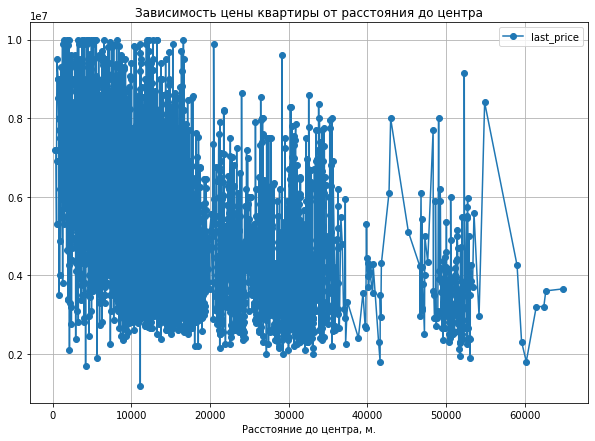

```python
# Зададим функцию, строящую график зависимости двух величин
# На вход подаются:
#    df - датафрейм
#    x - значения по оси Х
#    y - значения по оси У
#    titl - заголовок графика
#    xlbl - подпись оси Х
#    aggf - функция усреднения (по умолчанию - среднее)
#    figsz - размер графика (по умолчанию - (10, 7))
def build_plot(df, x, y, titl, xlbl, aggf='mean', figsz=(10, 7)):
    df.pivot_table(
        index=x,
        values=y,
        aggfunc=aggf
    ).plot(
        title=titl,
        figsize=figsz,
        grid=True,
        style='o-',
        xlabel=xlbl
    )
    plt.show()

# # Построим графики зависимости стоимости от параметров
build_plot(good_realty, 'total_area', 'last_price',
          'Зависимость цены квартиры от площади', 'Площадь квартиры, кв.м.')
build_plot(good_realty, 'rooms', 'last_price',
          'Зависимость цены квартиры от количества комнат', 'Количество комнат')
build_plot(good_realty, 'city_centers_nearest', 'last_price',
          'Зависимость цены квартиры от расстояния до центра', 'Расстояние до центра, м.')
```

Очевидно, график лучше гистограммы отражает зависимость усреднённой цены от дискретной величины. Мы видим, что, начиная с 3 комнат рост стоимости существенно замедляется.

#### Зависимость стоимости квартиры от этажа

Рассмотрим теперь зависимость стоимости квартиры `'last_price'` от этажа `'floor_cat'`. Вычислить коэффициент корреляции Пирсона для этих параметров невозможно, т.к. один из них строковый. Однако, корреляцию можно оценить со значением этажа `'floor'`:

```python
good_realty['last_price'].corr(good_realty['floor'])
```

```
0.1642333042115989
```

Отметим, что корреляция цены с этажом самая слабая, по сравнению с рассмотренными выше параметрами. Выведем для данных параметров диаграмму рассеяния, снизив прозрачность:

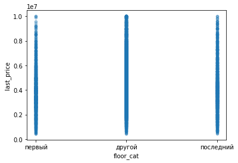

```python
good_realty.plot(x='floor_cat', y='last_price', kind='scatter', alpha=0.2)
plt.show()
```

На диаграмме отчётливо видно, что дорогие квартиры на первом и последнем этаже ценятся меньше. В нижнем и среднем ценовом диапазоне спрос на первый и последний этажи почти не отличается от спроса на любой другой этаж.

Построим график зависимости средней цены квартиры от этажа:

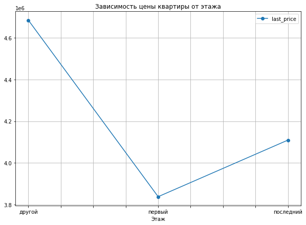

```python
build_plot(good_realty, 'floor_cat', 'last_price',
          'Зависимость цены квартиры от этажа', 'Этаж')
```

Очевидно, меньше всего ценится первый этаж по причине близости к подвалу и повышенных рисков.

Последние этажи - чуть дороже, но не так ценятся как средние этажи дома. Это объясняется близостью к крыше, техническому этажу и коммуникациям, что опять-таки повышает риски владения.

#### Зависимость стоимости квартиры от от дня недели, месяца и года размещения объявления

Рассмотрим зависимость стоимости квартиры `'last_price'` от дня недели `'first_exposition_weekday'`, месяца `'first_exposition_month'` и года размещения объявления `'first_exposition_year'`.

Построим матрицу попарной корреляции Пирсона для этих параметров, поскольку все они числовые:

```python
columns = ['last_price', 'first_exposition_weekday',
           'first_exposition_month', 'first_exposition_year']
good_realty[columns].corr().style.background_gradient('coolwarm')
```

|  | last_price | first_exposition_weekday | first_exposition_month | first_exposition_year |
| --- | --- | --- | --- | --- |
| last_price | 1.000000 | -0.009458 | 0.003674 | 0.012671 |
| first_exposition_weekday | -0.009458 | 1.000000 | 0.011235 | -0.002818 |
| first_exposition_month | 0.003674 | 0.011235 | 1.000000 | -0.231484 |
| first_exposition_year | 0.012671 | -0.002818 | -0.231484 | 1.000000 |

Очевидно, ежедневная и ежемесячная корреляция - очень слабые. При этом в рабочие дни квартиры продаются дороже, чем в конце.

Наиболее сильно цена квартир связана с годом. Что может объясняться годовыми изменениями экономической ситуации и движениями рынка.

Построим попарные диаграммы рассеивания для данных столбцов для иллюстрации указанных закономерностей:

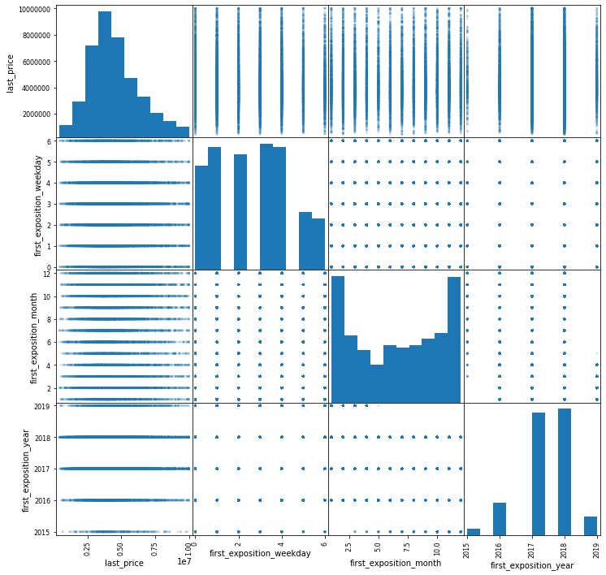

```python
pd.plotting.scatter_matrix(good_realty[['last_price', 'first_exposition_weekday',
                                        'first_exposition_month', 'first_exposition_year']],
                          grid=True, figsize=(12, 12), alpha=0.2)
plt.show()
```

На основании диаграмм можно сделать следующие наблюдения и выводы:

- в субботу и воскресенье одновременно уменьшается как количество размещаемых объявлений, так и средняя цена проданных квартир
- пики размещений приходятся на январь и декабрь, при этом можно заметить некоторое снижение средней цены, что объясняется пред- и постновогодними скидками
- объёмы размещений постепенно падают с февраля по апрель, в мае возобновляют рост и держатся приблизительно на одном уровне до декабря
- отчётливо видно, что в 2015, 2016 гг. наблюдалось проседание рынка, что повлияло на среднюю стоимость проданных квартир (данных за 2019 год недостаточно, чтобы следать аналогичный вывод)
- на диаграмме зависимости месяца от года можно оценить охват анализируемой выборки объяалений - с марта 2015 по май 2019 годов

На диаграммах рассеяния плохо исследовать зависимость цены от дискретных величин. Зато дискретные значения дней недели, месяцев и лет, а также зависимость от них средней цены квартир удобно и наглядно изобразить на графиках:

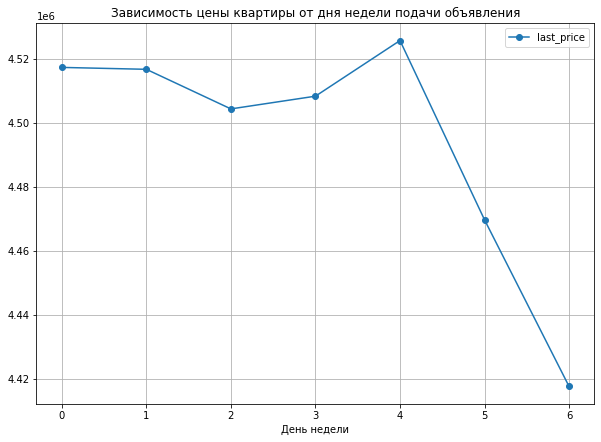

```python
build_plot(good_realty, 'first_exposition_weekday', 'last_price',
          'Зависимость цены квартиры от дня недели подачи объявления', 'День недели')
```

Стоимость квартир слабо колеблется в течение недели, а в выходные продавцы охотнее идут на уступки.

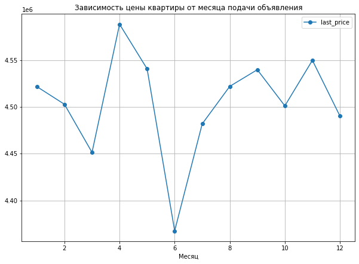

```python
build_plot(good_realty, 'first_exposition_month', 'last_price',
          'Зависимость цены квартиры от месяца подачи объявления', 'Месяц')
```

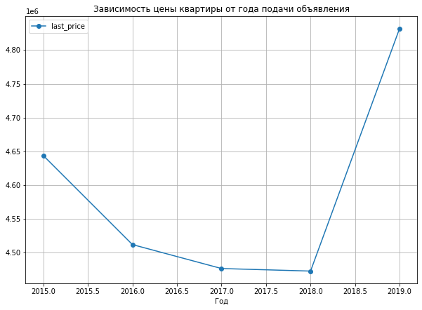

```python
build_plot(good_realty, 'first_exposition_year', 'last_price',
          'Зависимость цены квартиры от года подачи объявления', 'Год')
```

На графике наглядно представлено, как увеличение предложения в 2017 и 2018 годах привело к снижению средней стоимости квартиры. Рынок в действии!

К сожалению, данные представлены не за целый 2019 год. Поэтому сложно объяснить столь резкий рост средней цены за квартиру в этом году.

### Анализ 10 населённых пунктов с наибольшим количеством объявлений

Отберём 10 населённых пунктов с наибольшим количеством объявлений и отсортируем их по убыванию средней цены квадратного метра:

```python
# Составим сводную таблицу по городам с:
#   - количеством объявлений
#   - средней ценой квадратного метра
#   - медианной ценой квадратного метра
top_10_city_exposition = good_realty.pivot_table(
    index='locality_name',
    values='price_per_m2',
    aggfunc=['count', 'mean', 'median']
)

# Переименуем колонки
top_10_city_exposition.columns = ['count', 'price_m2_mean', 'price_m2_median']

# выделим 10 городов с наибольшим количеством объявлений
top_10_city_exposition = top_10_city_exposition.sort_values(by='count', ascending=False).head(10)

# Отсортируем по среднему
top_10_city_exposition.sort_values(by='price_m2_mean', ascending=False)
```

| locality_name | count | price_m2_mean | price_m2_median |
| --- | --- | --- | --- |
| Санкт-Петербург | 10215 | 103406.838193 | 100214.750 |
| Пушкин | 251 | 99141.844622 | 97451.270 |
| деревня Кудрово | 262 | 92584.513626 | 91901.640 |
| посёлок Парголово | 282 | 89163.305780 | 91138.910 |
| посёлок Мурино | 475 | 85969.843326 | 86268.870 |
| посёлок Шушары | 377 | 77787.199682 | 75917.740 |
| Колпино | 279 | 74668.846810 | 73728.810 |
| Гатчина | 238 | 68270.643067 | 67180.705 |
| Всеволожск | 297 | 66528.626835 | 65540.540 |
| Выборг | 179 | 57059.266816 | 56756.760 |

Среди 10 городов с наибольшим количеством объявлений дороже всего квадратные метры в Санкт-Петербурге, Пушкине, Кудрово. Дешевле всего - в Выборге, Всеволжске и Гатчине.

### Изучение предложения квартир в Санкт-Петербурге

Выделим предложение квартир в Санкт-Петербурге:

```python
piter_realty = good_realty.query('locality_name == "Санкт-Петербург"').copy()
piter_realty.head(2)
```

|  | total_images | last_price | total_area | first_day_exposition | rooms | ceiling_height | floors_total | living_area | floor | is_apartment | ... | ponds_around_3000 | ponds_nearest | days_exposition | price_per_m2 | first_exposition_weekday | first_exposition_month | first_exposition_year | floor_cat | living_ratio | kitchen_ratio |
| --- | --- | --- | --- | --- | --- | --- | --- | --- | --- | --- | --- | --- | --- | --- | --- | --- | --- | --- | --- | --- | --- |
| 4 | 2 | 10000000.0 | 100.0 | 2018-06-19 | 2 | 3.03 | 14 | 32.0 | 13 | False | ... | 1.0 | 48.0 | 121 | 100000.00 | 1 | 6 | 2018 | другой | 0.32 | 0.41 |
| 9 | 18 | 5400000.0 | 61.0 | 2017-02-26 | 3 | 2.50 | 9 | 43.6 | 7 | False | ... | 0.0 | NaN | 289 | 88524.59 | 6 | 2 | 2017 | другой | 0.71 | 0.11 |

2 rows × 29 columns

Создадим столбец с расстоянием до центра в колометрах и рассмотрим его характеристики:

```python
# Переведём расстояния в километры
piter_realty['city_centers_nearest_km'] = piter_realty['city_centers_nearest']\
                                                    .apply(lambda x: x / 1000)
# Проверим результат
piter_realty['city_centers_nearest_km'].describe()
```

```
count    10215.000000
mean        12.738503
std          4.209802
min          0.329000
25%         10.667000
50%         13.053000
75%         15.365000
max         29.493000
Name: city_centers_nearest_km, dtype: float64
```

Среднее довольно близко к медиане. Наблюдается довольно большое отклонение - возможно люди по-разному измеряют расстояние: одни по дорогам, другие - напрямую.

Удивление вызывают 29 километров от центра - неужели Питер такой большой?

Приведём столбец километров к целому типу:

```python
piter_realty['city_centers_nearest_km'] = piter_realty['city_centers_nearest_km'].astype('int')
```

Вычислим среднюю цену для каждого километра и построим график зависимости:

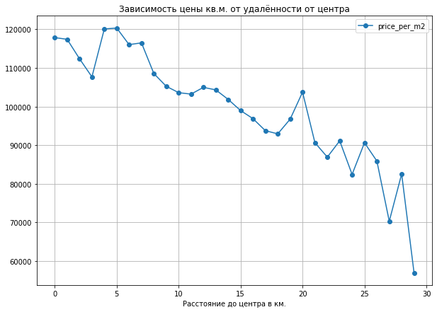

```python
build_plot(piter_realty, 'city_centers_nearest_km', 'price_per_m2',
          'Зависимость цены кв.м. от удалённости от центра', 'Расстояние до центра в км.')
```

График показывает, что, начиная с 7 километра, стоимость квадратного метра снижается. Значит **зону центра можно ограничить 7 километрами**.

Удивление вызывают артефакты в центральной зоне (на расстоянии от 0 до 4 км.), а также на периферии (на расстоянии свыше 18 км.).

Артефакты на большом расстоянии могут говорить о, мягко говоря, странной ценовой политике застройщиков новых высотных жилых кварталов.

Причину артефактов в центре предположить сложно. Скорее всего в ходе исследований мы удалили слишком мого записей, посчитав их выбросами по отдельным параметрам.

Для сравнения построим аналогичный график по неочищенным данным, только в качестве функции аггрегации применим медиану, как более устойчивую к выбросам:

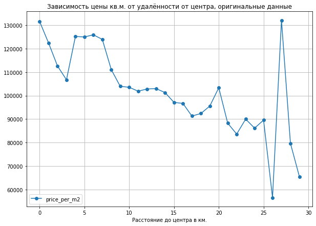

```python
piter_realty_original = realty.query('locality_name == "Санкт-Петербург"').copy()

# Переведём расстояния в километры
piter_realty_original['city_centers_nearest_km'] = piter_realty_original['city_centers_nearest']\
                                                    .apply(lambda x: x / 1000)
piter_realty_original['city_centers_nearest_km'] = piter_realty_original['city_centers_nearest_km']\
                                                    .astype('int')
# Построим график
build_plot(piter_realty_original, 'city_centers_nearest_km', 'price_per_m2',
           'Зависимость цены кв.м. от удалённости от центра, оригинальные данные',
           'Расстояние до центра в км.', aggf='median')
```

Очевидна аналогичная тенденция. Зона центра расширилась до 8 км., однако поведение графика в ней указывает что в стреднем на протяжении 2015-2019 гг. в 4-километровой зоне квартиры продавались по заниженным ценам, а на периферии - наоборот.